# Introduction to Computer Vision: COVID-19 Image Classification

## Problem Statement

### Context

Covid-19 is a fast-growing disease that affects human health severly. Patients diagonised with this condition suffers from lung infection. The medical community has recently released vaccines which have a slower effect in increasing the immunity. This virus has impacted various countries' human health and financial standing.

Deep learning algorithms have recently used image classification to identify medical images. Convolutional Neural Networks (CNN) can be widely utilized to identify COVID-19 to assist radiologists in medical analysis by classifying patients who are healthy, have viral pneumonia, or are affected by COVID using X-ray pictures of the lungs.

### Objective

The aim of this project is to Build a Convolutional Neural Network to differentiate an X-ray image of a person affected with covid from that of a healthy person or a person who has viral pneumonia(fever).

### Data Dictionary

- This dataset contains training set images of 3 classes which are converted into numpy arrays.
- The dataset comprises 3 classes:
  - COVID-19: The patient who is effected due to covid.
  - Viral Pneumonia: This is a viral fever which has similar characteristics like fever and cought that of Covid but is not covid.
  - Normal- A healthy Person with no symptoms of covid or fever.
- The data file names are:
  - CovidImages.npy
  - CovidLabels.csv

#### **Note: Please use GPU runtime to execute the code efficiently**

## Importing necessary libraries

```python
# Installing the libraries with the specified version.
# uncomment and run the following line if Google Colab is being used
#!pip install tensorflow==2.15.0 scikit-learn==1.2.2 seaborn==0.13.1 matplotlib==3.7.1 numpy==1.25.2 pandas==1.5.3 opencv-python==4.8.0.76 -q --user
```

```python
# Installing the libraries with the specified version.
# uncomment and run the following lines if Jupyter Notebook is being used
#!pip install tensorflow==2.13.0 scikit-learn==1.2.2 seaborn==0.13.1 matplotlib==3.7.1 numpy==1.25.2 pandas==1.5.3 opencv-python==4.8.0.76 -q --user
```

**Note**: *After running the above cell, kindly restart the notebook kernel and run all cells sequentially from the start again.*

```python
import os
import numpy as np                                                                               # Importing numpy for Matrix Operations
import pandas as pd                                                                              # Importing pandas to read CSV files
import matplotlib.pyplot as plt                                                                  # Importing matplotlib for Plotting and visualizing images
import math                                                                                      # Importing math module to perform mathematical operations
import cv2                                                                                       # Importing openCV for image processing
import seaborn as sns                                                                            # Importing seaborn to plot graphs


# Tensorflow modules
import tensorflow as tf
from tensorflow.keras.preprocessing.image import ImageDataGenerator                              # Importing the ImageDataGenerator for data augmentation
from tensorflow.keras.models import Sequential                                                   # Importing the sequential module to define a sequential model
from tensorflow.keras.layers import Dense,Dropout,Flatten,Conv2D,MaxPooling2D,BatchNormalization # Defining all the layers to build our CNN Model
from tensorflow.keras.optimizers import Adam,SGD                                                 # Importing the optimizers which can be used in our model
from sklearn import preprocessing                                                                # Importing the preprocessing module to preprocess the data
from sklearn.model_selection import train_test_split                                             # Importing train_test_split function to split the data into train and test
from sklearn.metrics import confusion_matrix                                                     # Importing confusion_matrix to plot the confusion matrix
from sklearn.preprocessing import LabelBinarizer
# Display images using OpenCV
from google.colab.patches import cv2_imshow
#from google.colab.patches import cv2_imshow                                                      # Importing cv2_imshow from google.patches to display images
from sklearn.model_selection import train_test_split
from tensorflow.keras import backend
from keras.callbacks import ReduceLROnPlateau
import random
# Ignore warnings
import warnings
warnings.filterwarnings('ignore')
```

## Loading the dataset

```python
# Mount Google drive to access the dataset
# Run the below code if you using google colab
from google.colab import drive
drive.mount('/content/drive')
```

```python
# Load the image file of dataset
images = np.load('/content/drive/MyDrive/Colab_Notebooks/202409_CompVision/FinalProject/CovidImages.npy')

# Load the labels file of dataset
labels = pd.read_csv('/content/drive/MyDrive/Colab_Notebooks/202409_CompVision/FinalProject/CovidLabels.csv')
```

## Data Overview

### Understand the shape of the dataset

```python
print(images.shape)
print(labels.shape)
```

```
(251, 128, 128, 3)
(251, 1)
```

There are 251 RGB images of shape 128 x 128 X 3, each image having 3 channels.

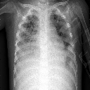

```python
cv2_imshow(images[4])
```

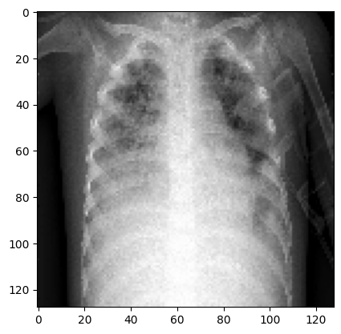

```python
plt.imshow(images[4])
```

- We can observe that the images are being shown in same colors.

## Exploratory Data Analysis

- EDA is an important part of any project involving data.
- It is important to investigate and understand the data better before building a model with it.
- A few questions have been mentioned below which will help you understand the data better.
- A thorough analysis of the data, in addition to the questions mentioned below, should be done.
1. How are these different category X-ray images different from each other?
2. Is the dataset provided an imbalance? (Check with using bar plots)

### Plotting random images from each of the class

```python
def plot_images(images,labels):
  num_classes=10                                                                  # Number of Classes
  categories=np.unique(labels)
  keys=dict(labels['Label'])                                                      # Obtaing the unique classes from y_train
  rows = 3                                                                        # Defining number of rows=3
  cols = 4                                                                        # Defining number of columns=4
  fig = plt.figure(figsize=(10, 8))                                               # Defining the figure size to 10x8
  for i in range(cols):
      for j in range(rows):
          random_index = np.random.randint(0, len(labels))                        # Generating random indices from the data and plotting the images
          ax = fig.add_subplot(rows, cols, i * rows + j + 1)                      # Adding subplots with 3 rows and 4 columns
          ax.imshow(images[random_index, :])                                      # Plotting the image
          ax.set_title(keys[random_index])
  plt.show()
```

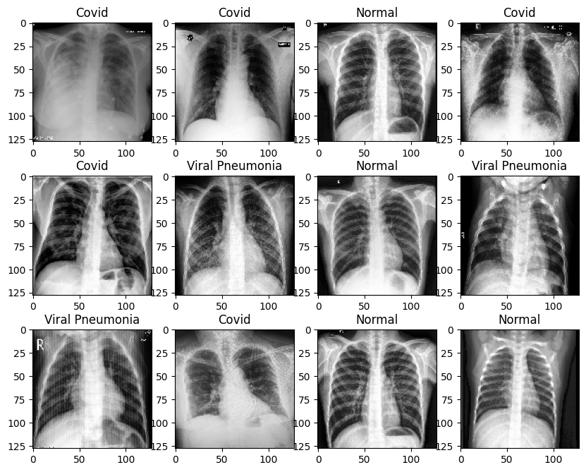

```python
plot_images(images,labels)
```

### Checking the distribution of the target variable

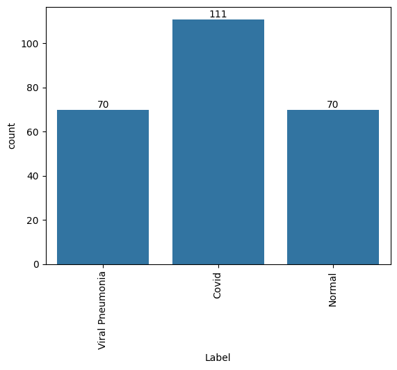

```python
ax = sns.countplot(x=labels['Label'])
plt.xticks(rotation='vertical')

for i in ax.containers:
    ax.bar_label(i,)
```

## Data Pre-Processing

### Converting the BGR images to RGB images

```python
for i in range(len(images)):
  images[i] = cv2.cvtColor(images[i], cv2.COLOR_BGR2RGB)
```

### Resize the images

As the size of the images is large, it may be computationally expensive to train on these larger images; therefore, it is preferable to reduce the image size from 128 to 64.

```python
images_decreased=[]
height = 64
width = 64
dimensions =(height,width)
for i in range(len(images)):
  images_decreased.append(cv2.resize(images[i], dimensions, interpolation=cv2.INTER_LINEAR))
```

**Image before resizing**

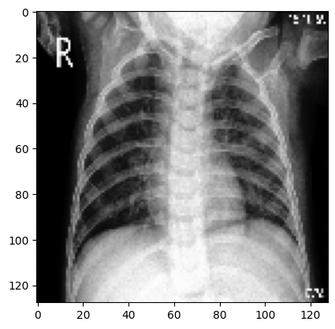

```python
plt.imshow(images[8])
```

**Image after resizing**

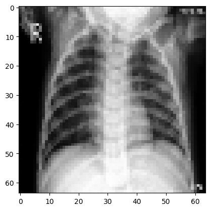

```python
plt.imshow(images_decreased[8])
```

### Data Preparation for Modeling

- Before you proceed to build a model, you need to split the data into train, test, and validation to be able to evaluate the model that you build on the train data
- You'll have to encode categorical features and scale the pixel values.
- You will build a model using the train data and then check its performance

**Split the dataset**

```python
X_temp, X_test, y_temp, y_test = train_test_split(np.array(images_decreased),labels , test_size=0.1, random_state=42,stratify=labels)
X_train, X_val, y_train, y_val = train_test_split(X_temp,y_temp , test_size=0.1, random_state=42,stratify=y_temp)
```

```python
print(X_train.shape,y_train.shape)
print(X_val.shape,y_val.shape)
print(X_test.shape,y_test.shape)
```

```
(202, 64, 64, 3) (202, 1)
(23, 64, 64, 3) (23, 1)
(26, 64, 64, 3) (26, 1)
```

### Encode the target labels

```python
# Convert labels from names to one hot vectors.
enc = LabelBinarizer()
y_train_encoded = enc.fit_transform(y_train)
y_val_encoded=enc.transform(y_val)
y_test_encoded=enc.transform(y_test)
```

```python
y_train_encoded.shape,y_val_encoded.shape,y_test_encoded.shape
```

```
((202, 3), (23, 3), (26, 3))
```

### Data Normalization

```python
# Normalizing the image pixels
X_train_normalized = X_train.astype('float32')/255.0
X_val_normalized = X_val.astype('float32')/255.0
X_test_normalized = X_test.astype('float32')/255.0
```

## Model Building

```python
# Clearing backend
backend.clear_session()
```

```python
# Fixing the seed for random number generators
np.random.seed(42)
random.seed(42)
tf.random.set_seed(42)
```

```python
# Intializing a sequential model
model1 = Sequential()

# Adding first conv layer with 128 filters and kernel size 3x3 , padding 'same' provides the output size same as the input size
# Input_shape denotes input image dimension of images
model1.add(Conv2D(128, (3, 3), activation='relu', padding="same", input_shape=(64, 64, 3)))

# Adding max pooling to reduce the size of output of first conv layer
model1.add(MaxPooling2D((2, 2), padding = 'same'))

# Creating two similar convolution and max-pooling layers
model1.add(Conv2D(64, (3, 3), activation='relu', padding="same"))
model1.add(MaxPooling2D((2, 2), padding = 'same'))

model1.add(Conv2D(32, (3, 3), activation='relu', padding="same"))
model1.add(MaxPooling2D((2, 2), padding = 'same'))

# flattening the output of the conv layer after max pooling to make it ready for creating dense connections
model1.add(Flatten())

# Adding a fully connected dense layer with 16 neurons
model1.add(Dense(16, activation='relu'))
model1.add(Dropout(0.3))
# Adding the output layer with 3 neurons and activation functions as softmax since this is a multi-class classification problem
model1.add(Dense(3, activation='softmax'))

opt=Adam()
# Compile model
model1.compile(optimizer=opt, loss='categorical_crossentropy', metrics=['accuracy'])

# Generating the summary of the model
model1.summary()
```

```
Model: "sequential"
```

```
┏━━━━━━━━━━━━━━━━━━━━━━━━━━━━━━━━━━━━━━┳━━━━━━━━━━━━━━━━━━━━━━━━━━━━━┳━━━━━━━━━━━━━━━━━┓
┃ Layer (type)                         ┃ Output Shape                ┃         Param # ┃
┡━━━━━━━━━━━━━━━━━━━━━━━━━━━━━━━━━━━━━━╇━━━━━━━━━━━━━━━━━━━━━━━━━━━━━╇━━━━━━━━━━━━━━━━━┩
│ conv2d (Conv2D)                      │ (None, 64, 64, 128)         │           3,584 │
├──────────────────────────────────────┼─────────────────────────────┼─────────────────┤
│ max_pooling2d (MaxPooling2D)         │ (None, 32, 32, 128)         │               0 │
├──────────────────────────────────────┼─────────────────────────────┼─────────────────┤
│ conv2d_1 (Conv2D)                    │ (None, 32, 32, 64)          │          73,792 │
├──────────────────────────────────────┼─────────────────────────────┼─────────────────┤
│ max_pooling2d_1 (MaxPooling2D)       │ (None, 16, 16, 64)          │               0 │
├──────────────────────────────────────┼─────────────────────────────┼─────────────────┤
│ conv2d_2 (Conv2D)                    │ (None, 16, 16, 32)          │          18,464 │
├──────────────────────────────────────┼─────────────────────────────┼─────────────────┤
│ max_pooling2d_2 (MaxPooling2D)       │ (None, 8, 8, 32)            │               0 │
├──────────────────────────────────────┼─────────────────────────────┼─────────────────┤
│ flatten (Flatten)                    │ (None, 2048)                │               0 │
├──────────────────────────────────────┼─────────────────────────────┼─────────────────┤
│ dense (Dense)                        │ (None, 16)                  │          32,784 │
├──────────────────────────────────────┼─────────────────────────────┼─────────────────┤
│ dropout (Dropout)                    │ (None, 16)                  │               0 │
├──────────────────────────────────────┼─────────────────────────────┼─────────────────┤
│ dense_1 (Dense)                      │ (None, 3)                   │              51 │
└──────────────────────────────────────┴─────────────────────────────┴─────────────────┘
```

```
 Total params: 128,675 (502.64 KB)
```

```
 Trainable params: 128,675 (502.64 KB)
```

```
 Non-trainable params: 0 (0.00 B)
```

**Fitting the model on the train data**

```python
history_1 = model1.fit(
            X_train_normalized, y_train_encoded,
            epochs=30,
            validation_data=(X_val_normalized,y_val_encoded),
            batch_size=64,
            verbose=1
)
```

```
1/4 ━━━━━━━━━━━━━━━━━━━━ 8s 3s/step - accuracy: 0.5469 - loss: 1.0644
```

```
2/4 ━━━━━━━━━━━━━━━━━━━━ 2s 1s/step - accuracy: 0.5117 - loss: 1.0868
```

```
3/4 ━━━━━━━━━━━━━━━━━━━━ 1s 1s/step - accuracy: 0.4887 - loss: 1.0939
```

```
4/4 ━━━━━━━━━━━━━━━━━━━━ 0s 821ms/step - accuracy: 0.4730 - loss: 1.0974
```

```
4/4 ━━━━━━━━━━━━━━━━━━━━ 6s 935ms/step - accuracy: 0.4635 - loss: 1.0995 - val_accuracy: 0.5652 - val_loss: 1.0818
```

```
1/4 ━━━━━━━━━━━━━━━━━━━━ 6s 2s/step - accuracy: 0.4375 - loss: 1.0847
```

```
2/4 ━━━━━━━━━━━━━━━━━━━━ 2s 1s/step - accuracy: 0.4336 - loss: 1.0848
```

```
3/4 ━━━━━━━━━━━━━━━━━━━━ 1s 1s/step - accuracy: 0.4245 - loss: 1.0846
```

```
4/4 ━━━━━━━━━━━━━━━━━━━━ 0s 1s/step - accuracy: 0.4198 - loss: 1.0842
```

```
4/4 ━━━━━━━━━━━━━━━━━━━━ 6s 1s/step - accuracy: 0.4171 - loss: 1.0840 - val_accuracy: 0.4348 - val_loss: 1.0586
```

```
1/4 ━━━━━━━━━━━━━━━━━━━━ 5s 2s/step - accuracy: 0.5781 - loss: 1.0458
```

```
2/4 ━━━━━━━━━━━━━━━━━━━━ 3s 2s/step - accuracy: 0.5312 - loss: 1.0507
```

```
3/4 ━━━━━━━━━━━━━━━━━━━━ 1s 2s/step - accuracy: 0.5017 - loss: 1.0515
```

```
4/4 ━━━━━━━━━━━━━━━━━━━━ 0s 1s/step - accuracy: 0.4865 - loss: 1.0518
```

```
4/4 ━━━━━━━━━━━━━━━━━━━━ 5s 1s/step - accuracy: 0.4773 - loss: 1.0520 - val_accuracy: 0.4348 - val_loss: 1.0121
```

```
1/4 ━━━━━━━━━━━━━━━━━━━━ 18s 6s/step - accuracy: 0.5781 - loss: 0.9852
```

```
2/4 ━━━━━━━━━━━━━━━━━━━━ 2s 1s/step - accuracy: 0.5312 - loss: 1.0040
```

```
3/4 ━━━━━━━━━━━━━━━━━━━━ 1s 1s/step - accuracy: 0.5017 - loss: 1.0093
```

```
4/4 ━━━━━━━━━━━━━━━━━━━━ 0s 867ms/step - accuracy: 0.4865 - loss: 1.0111
```

```
4/4 ━━━━━━━━━━━━━━━━━━━━ 9s 930ms/step - accuracy: 0.4773 - loss: 1.0123 - val_accuracy: 0.4348 - val_loss: 0.9529
```

```
1/4 ━━━━━━━━━━━━━━━━━━━━ 8s 3s/step - accuracy: 0.5781 - loss: 0.9411
```

```
2/4 ━━━━━━━━━━━━━━━━━━━━ 3s 2s/step - accuracy: 0.5312 - loss: 0.9638
```

```
3/4 ━━━━━━━━━━━━━━━━━━━━ 1s 1s/step - accuracy: 0.5017 - loss: 0.9684
```

```
4/4 ━━━━━━━━━━━━━━━━━━━━ 0s 1s/step - accuracy: 0.4865 - loss: 0.9700
```

```
4/4 ━━━━━━━━━━━━━━━━━━━━ 6s 1s/step - accuracy: 0.4773 - loss: 0.9709 - val_accuracy: 0.4783 - val_loss: 0.8742
```

```
1/4 ━━━━━━━━━━━━━━━━━━━━ 4s 1s/step - accuracy: 0.5781 - loss: 0.8377
```

```
2/4 ━━━━━━━━━━━━━━━━━━━━ 2s 1s/step - accuracy: 0.5547 - loss: 0.8689
```

```
3/4 ━━━━━━━━━━━━━━━━━━━━ 1s 1s/step - accuracy: 0.5503 - loss: 0.8785
```

```
4/4 ━━━━━━━━━━━━━━━━━━━━ 0s 808ms/step - accuracy: 0.5514 - loss: 0.8832
```

```
4/4 ━━━━━━━━━━━━━━━━━━━━ 4s 854ms/step - accuracy: 0.5520 - loss: 0.8861 - val_accuracy: 0.6522 - val_loss: 0.8335
```

```
1/4 ━━━━━━━━━━━━━━━━━━━━ 7s 2s/step - accuracy: 0.6875 - loss: 0.8077
```

```
2/4 ━━━━━━━━━━━━━━━━━━━━ 2s 1s/step - accuracy: 0.6758 - loss: 0.8286
```

```
3/4 ━━━━━━━━━━━━━━━━━━━━ 1s 1s/step - accuracy: 0.6641 - loss: 0.8379
```

```
4/4 ━━━━━━━━━━━━━━━━━━━━ 0s 912ms/step - accuracy: 0.6602 - loss: 0.8416
```

```
4/4 ━━━━━━━━━━━━━━━━━━━━ 6s 1s/step - accuracy: 0.6578 - loss: 0.8439 - val_accuracy: 0.6522 - val_loss: 0.7878
```

```
1/4 ━━━━━━━━━━━━━━━━━━━━ 8s 3s/step - accuracy: 0.7031 - loss: 0.7174
```

```
2/4 ━━━━━━━━━━━━━━━━━━━━ 3s 2s/step - accuracy: 0.6523 - loss: 0.7717
```

```
3/4 ━━━━━━━━━━━━━━━━━━━━ 1s 2s/step - accuracy: 0.6224 - loss: 0.7925
```

```
4/4 ━━━━━━━━━━━━━━━━━━━━ 0s 1s/step - accuracy: 0.6104 - loss: 0.8013
```

```
4/4 ━━━━━━━━━━━━━━━━━━━━ 7s 1s/step - accuracy: 0.6031 - loss: 0.8065 - val_accuracy: 0.6522 - val_loss: 0.7650
```

```
1/4 ━━━━━━━━━━━━━━━━━━━━ 16s 5s/step - accuracy: 0.7656 - loss: 0.6968
```

```
2/4 ━━━━━━━━━━━━━━━━━━━━ 2s 1s/step - accuracy: 0.7422 - loss: 0.7335
```

```
3/4 ━━━━━━━━━━━━━━━━━━━━ 1s 1s/step - accuracy: 0.7240 - loss: 0.7484
```

```
4/4 ━━━━━━━━━━━━━━━━━━━━ 0s 1s/step - accuracy: 0.7162 - loss: 0.7550
```

```
4/4 ━━━━━━━━━━━━━━━━━━━━ 9s 1s/step - accuracy: 0.7116 - loss: 0.7590 - val_accuracy: 0.6522 - val_loss: 0.7099
```

```
1/4 ━━━━━━━━━━━━━━━━━━━━ 7s 3s/step - accuracy: 0.7031 - loss: 0.7187
```

```
2/4 ━━━━━━━━━━━━━━━━━━━━ 2s 1s/step - accuracy: 0.6797 - loss: 0.7611
```

```
3/4 ━━━━━━━━━━━━━━━━━━━━ 1s 1s/step - accuracy: 0.6684 - loss: 0.7751
```

```
4/4 ━━━━━━━━━━━━━━━━━━━━ 0s 919ms/step - accuracy: 0.6647 - loss: 0.7803
```

```
4/4 ━━━━━━━━━━━━━━━━━━━━ 5s 964ms/step - accuracy: 0.6624 - loss: 0.7835 - val_accuracy: 0.6522 - val_loss: 0.7223
```

```
1/4 ━━━━━━━━━━━━━━━━━━━━ 4s 1s/step - accuracy: 0.7656 - loss: 0.6533
```

```
2/4 ━━━━━━━━━━━━━━━━━━━━ 2s 1s/step - accuracy: 0.7383 - loss: 0.7029
```

```
3/4 ━━━━━━━━━━━━━━━━━━━━ 1s 1s/step - accuracy: 0.7196 - loss: 0.7233
```

```
4/4 ━━━━━━━━━━━━━━━━━━━━ 0s 807ms/step - accuracy: 0.7117 - loss: 0.7323
```

```
4/4 ━━━━━━━━━━━━━━━━━━━━ 4s 848ms/step - accuracy: 0.7070 - loss: 0.7377 - val_accuracy: 0.6522 - val_loss: 0.7211
```

```
1/4 ━━━━━━━━━━━━━━━━━━━━ 3s 1s/step - accuracy: 0.7656 - loss: 0.6258
```

```
2/4 ━━━━━━━━━━━━━━━━━━━━ 2s 1s/step - accuracy: 0.7422 - loss: 0.6740
```

```
3/4 ━━━━━━━━━━━━━━━━━━━━ 1s 1s/step - accuracy: 0.7257 - loss: 0.6948
```

```
4/4 ━━━━━━━━━━━━━━━━━━━━ 0s 806ms/step - accuracy: 0.7188 - loss: 0.7041
```

```
4/4 ━━━━━━━━━━━━━━━━━━━━ 4s 850ms/step - accuracy: 0.7146 - loss: 0.7097 - val_accuracy: 0.6522 - val_loss: 0.6783
```

```
1/4 ━━━━━━━━━━━━━━━━━━━━ 9s 3s/step - accuracy: 0.7812 - loss: 0.5871
```

```
2/4 ━━━━━━━━━━━━━━━━━━━━ 3s 2s/step - accuracy: 0.7539 - loss: 0.6262
```

```
3/4 ━━━━━━━━━━━━━━━━━━━━ 1s 1s/step - accuracy: 0.7352 - loss: 0.6477
```

```
4/4 ━━━━━━━━━━━━━━━━━━━━ 0s 1s/step - accuracy: 0.7272 - loss: 0.6579
```

```
4/4 ━━━━━━━━━━━━━━━━━━━━ 6s 1s/step - accuracy: 0.7223 - loss: 0.6640 - val_accuracy: 0.6522 - val_loss: 0.6769
```

```
1/4 ━━━━━━━━━━━━━━━━━━━━ 3s 1s/step - accuracy: 0.7656 - loss: 0.5547
```

```
2/4 ━━━━━━━━━━━━━━━━━━━━ 2s 1s/step - accuracy: 0.7383 - loss: 0.6440
```

```
3/4 ━━━━━━━━━━━━━━━━━━━━ 1s 1s/step - accuracy: 0.7196 - loss: 0.6727
```

```
4/4 ━━━━━━━━━━━━━━━━━━━━ 0s 810ms/step - accuracy: 0.7117 - loss: 0.6863
```

```
4/4 ━━━━━━━━━━━━━━━━━━━━ 4s 854ms/step - accuracy: 0.7070 - loss: 0.6945 - val_accuracy: 0.6522 - val_loss: 0.6764
```

```
1/4 ━━━━━━━━━━━━━━━━━━━━ 7s 3s/step - accuracy: 0.7344 - loss: 0.6284
```

```
2/4 ━━━━━━━━━━━━━━━━━━━━ 2s 1s/step - accuracy: 0.7188 - loss: 0.6764
```

```
3/4 ━━━━━━━━━━━━━━━━━━━━ 1s 1s/step - accuracy: 0.7066 - loss: 0.6932
```

```
4/4 ━━━━━━━━━━━━━━━━━━━━ 0s 940ms/step - accuracy: 0.7020 - loss: 0.7006
```

```
4/4 ━━━━━━━━━━━━━━━━━━━━ 6s 1s/step - accuracy: 0.6992 - loss: 0.7050 - val_accuracy: 0.6957 - val_loss: 0.6967
```

```
1/4 ━━━━━━━━━━━━━━━━━━━━ 8s 3s/step - accuracy: 0.7344 - loss: 0.5366
```

```
2/4 ━━━━━━━━━━━━━━━━━━━━ 2s 1s/step - accuracy: 0.6992 - loss: 0.6171
```

```
3/4 ━━━━━━━━━━━━━━━━━━━━ 1s 1s/step - accuracy: 0.6832 - loss: 0.6457
```

```
4/4 ━━━━━━━━━━━━━━━━━━━━ 0s 893ms/step - accuracy: 0.6770 - loss: 0.6597
```

```
4/4 ━━━━━━━━━━━━━━━━━━━━ 6s 936ms/step - accuracy: 0.6733 - loss: 0.6682 - val_accuracy: 0.6522 - val_loss: 0.6371
```

```
1/4 ━━━━━━━━━━━━━━━━━━━━ 4s 2s/step - accuracy: 0.7656 - loss: 0.5720
```

```
2/4 ━━━━━━━━━━━━━━━━━━━━ 2s 1s/step - accuracy: 0.7461 - loss: 0.6175
```

```
3/4 ━━━━━━━━━━━━━━━━━━━━ 1s 1s/step - accuracy: 0.7283 - loss: 0.6368
```

```
4/4 ━━━━━━━━━━━━━━━━━━━━ 0s 814ms/step - accuracy: 0.7207 - loss: 0.6465
```

```
4/4 ━━━━━━━━━━━━━━━━━━━━ 4s 858ms/step - accuracy: 0.7162 - loss: 0.6523 - val_accuracy: 0.6957 - val_loss: 0.6448
```

```
1/4 ━━━━━━━━━━━━━━━━━━━━ 3s 1s/step - accuracy: 0.7344 - loss: 0.6176
```

```
2/4 ━━━━━━━━━━━━━━━━━━━━ 2s 1s/step - accuracy: 0.7266 - loss: 0.6438
```

```
3/4 ━━━━━━━━━━━━━━━━━━━━ 1s 1s/step - accuracy: 0.7135 - loss: 0.6589
```

```
4/4 ━━━━━━━━━━━━━━━━━━━━ 0s 818ms/step - accuracy: 0.7084 - loss: 0.6659
```

```
4/4 ━━━━━━━━━━━━━━━━━━━━ 4s 878ms/step - accuracy: 0.7054 - loss: 0.6701 - val_accuracy: 0.6522 - val_loss: 0.6280
```

```
1/4 ━━━━━━━━━━━━━━━━━━━━ 9s 3s/step - accuracy: 0.7656 - loss: 0.5783
```

```
2/4 ━━━━━━━━━━━━━━━━━━━━ 3s 2s/step - accuracy: 0.7383 - loss: 0.6277
```

```
3/4 ━━━━━━━━━━━━━━━━━━━━ 1s 1s/step - accuracy: 0.7214 - loss: 0.6479
```

```
4/4 ━━━━━━━━━━━━━━━━━━━━ 0s 1s/step - accuracy: 0.7143 - loss: 0.6576
```

```
4/4 ━━━━━━━━━━━━━━━━━━━━ 6s 1s/step - accuracy: 0.7100 - loss: 0.6635 - val_accuracy: 0.6957 - val_loss: 0.6446
```

```
1/4 ━━━━━━━━━━━━━━━━━━━━ 3s 1s/step - accuracy: 0.7656 - loss: 0.5301
```

```
2/4 ━━━━━━━━━━━━━━━━━━━━ 2s 1s/step - accuracy: 0.7383 - loss: 0.5905
```

```
3/4 ━━━━━━━━━━━━━━━━━━━━ 1s 1s/step - accuracy: 0.7196 - loss: 0.6205
```

```
4/4 ━━━━━━━━━━━━━━━━━━━━ 0s 813ms/step - accuracy: 0.7117 - loss: 0.6347
```

```
4/4 ━━━━━━━━━━━━━━━━━━━━ 4s 857ms/step - accuracy: 0.7070 - loss: 0.6431 - val_accuracy: 0.6957 - val_loss: 0.6339
```

```
1/4 ━━━━━━━━━━━━━━━━━━━━ 7s 3s/step - accuracy: 0.7500 - loss: 0.5675
```

```
2/4 ━━━━━━━━━━━━━━━━━━━━ 2s 1s/step - accuracy: 0.7344 - loss: 0.6070
```

```
3/4 ━━━━━━━━━━━━━━━━━━━━ 1s 1s/step - accuracy: 0.7205 - loss: 0.6246
```

```
4/4 ━━━━━━━━━━━━━━━━━━━━ 0s 904ms/step - accuracy: 0.7149 - loss: 0.6331
```

```
4/4 ━━━━━━━━━━━━━━━━━━━━ 5s 970ms/step - accuracy: 0.7115 - loss: 0.6382 - val_accuracy: 0.6957 - val_loss: 0.6110
```

```
1/4 ━━━━━━━━━━━━━━━━━━━━ 8s 3s/step - accuracy: 0.7656 - loss: 0.5381
```

```
2/4 ━━━━━━━━━━━━━━━━━━━━ 2s 1s/step - accuracy: 0.7422 - loss: 0.5885
```

```
3/4 ━━━━━━━━━━━━━━━━━━━━ 1s 1s/step - accuracy: 0.7222 - loss: 0.6074
```

```
4/4 ━━━━━━━━━━━━━━━━━━━━ 0s 861ms/step - accuracy: 0.7137 - loss: 0.6164
```

```
4/4 ━━━━━━━━━━━━━━━━━━━━ 6s 909ms/step - accuracy: 0.7086 - loss: 0.6217 - val_accuracy: 0.6957 - val_loss: 0.6161
```

```
1/4 ━━━━━━━━━━━━━━━━━━━━ 5s 2s/step - accuracy: 0.7500 - loss: 0.5597
```

```
2/4 ━━━━━━━━━━━━━━━━━━━━ 2s 1s/step - accuracy: 0.7344 - loss: 0.5909
```

```
3/4 ━━━━━━━━━━━━━━━━━━━━ 1s 1s/step - accuracy: 0.7257 - loss: 0.6089
```

```
4/4 ━━━━━━━━━━━━━━━━━━━━ 0s 836ms/step - accuracy: 0.7225 - loss: 0.6178
```

```
4/4 ━━━━━━━━━━━━━━━━━━━━ 4s 880ms/step - accuracy: 0.7206 - loss: 0.6232 - val_accuracy: 0.7391 - val_loss: 0.6265
```

```
1/4 ━━━━━━━━━━━━━━━━━━━━ 7s 2s/step - accuracy: 0.7031 - loss: 0.6110
```

```
2/4 ━━━━━━━━━━━━━━━━━━━━ 2s 1s/step - accuracy: 0.7188 - loss: 0.6357
```

```
3/4 ━━━━━━━━━━━━━━━━━━━━ 1s 2s/step - accuracy: 0.7292 - loss: 0.6437
```

```
4/4 ━━━━━━━━━━━━━━━━━━━━ 0s 1s/step - accuracy: 0.7362 - loss: 0.6479
```

```
4/4 ━━━━━━━━━━━━━━━━━━━━ 6s 1s/step - accuracy: 0.7405 - loss: 0.6504 - val_accuracy: 0.8261 - val_loss: 0.5851
```

```
1/4 ━━━━━━━━━━━━━━━━━━━━ 6s 2s/step - accuracy: 0.7812 - loss: 0.5296
```

```
2/4 ━━━━━━━━━━━━━━━━━━━━ 2s 1s/step - accuracy: 0.7734 - loss: 0.5888
```

```
3/4 ━━━━━━━━━━━━━━━━━━━━ 1s 1s/step - accuracy: 0.7656 - loss: 0.6174
```

```
4/4 ━━━━━━━━━━━━━━━━━━━━ 0s 854ms/step - accuracy: 0.7623 - loss: 0.6314
```

```
4/4 ━━━━━━━━━━━━━━━━━━━━ 5s 898ms/step - accuracy: 0.7604 - loss: 0.6397 - val_accuracy: 0.8696 - val_loss: 0.5829
```

```
1/4 ━━━━━━━━━━━━━━━━━━━━ 4s 2s/step - accuracy: 0.7812 - loss: 0.5197
```

```
2/4 ━━━━━━━━━━━━━━━━━━━━ 2s 1s/step - accuracy: 0.7891 - loss: 0.5552
```

```
3/4 ━━━━━━━━━━━━━━━━━━━━ 1s 1s/step - accuracy: 0.7969 - loss: 0.5696
```

```
4/4 ━━━━━━━━━━━━━━━━━━━━ 0s 815ms/step - accuracy: 0.8006 - loss: 0.5773
```

```
4/4 ━━━━━━━━━━━━━━━━━━━━ 4s 860ms/step - accuracy: 0.8029 - loss: 0.5819 - val_accuracy: 0.7391 - val_loss: 0.6150
```

```
1/4 ━━━━━━━━━━━━━━━━━━━━ 7s 3s/step - accuracy: 0.7031 - loss: 0.5623
```

```
2/4 ━━━━━━━━━━━━━━━━━━━━ 2s 1s/step - accuracy: 0.7266 - loss: 0.5954
```

```
3/4 ━━━━━━━━━━━━━━━━━━━━ 1s 2s/step - accuracy: 0.7292 - loss: 0.6129
```

```
4/4 ━━━━━━━━━━━━━━━━━━━━ 0s 1s/step - accuracy: 0.7313 - loss: 0.6217
```

```
4/4 ━━━━━━━━━━━━━━━━━━━━ 6s 1s/step - accuracy: 0.7325 - loss: 0.6271 - val_accuracy: 0.7826 - val_loss: 0.6092
```

```
1/4 ━━━━━━━━━━━━━━━━━━━━ 6s 2s/step - accuracy: 0.6875 - loss: 0.5993
```

```
2/4 ━━━━━━━━━━━━━━━━━━━━ 2s 1s/step - accuracy: 0.7188 - loss: 0.6116
```

```
3/4 ━━━━━━━━━━━━━━━━━━━━ 1s 1s/step - accuracy: 0.7344 - loss: 0.6160
```

```
4/4 ━━━━━━━━━━━━━━━━━━━━ 0s 813ms/step - accuracy: 0.7426 - loss: 0.6185
```

```
4/4 ━━━━━━━━━━━━━━━━━━━━ 5s 857ms/step - accuracy: 0.7476 - loss: 0.6199 - val_accuracy: 0.8696 - val_loss: 0.5634
```

```
1/4 ━━━━━━━━━━━━━━━━━━━━ 5s 2s/step - accuracy: 0.8281 - loss: 0.4931
```

```
2/4 ━━━━━━━━━━━━━━━━━━━━ 2s 1s/step - accuracy: 0.8281 - loss: 0.5357
```

```
3/4 ━━━━━━━━━━━━━━━━━━━━ 1s 1s/step - accuracy: 0.8212 - loss: 0.5618
```

```
4/4 ━━━━━━━━━━━━━━━━━━━━ 0s 815ms/step - accuracy: 0.8176 - loss: 0.5752
```

```
4/4 ━━━━━━━━━━━━━━━━━━━━ 4s 859ms/step - accuracy: 0.8155 - loss: 0.5832 - val_accuracy: 0.8261 - val_loss: 0.5526
```

```
1/4 ━━━━━━━━━━━━━━━━━━━━ 7s 2s/step - accuracy: 0.7500 - loss: 0.5128
```

```
2/4 ━━━━━━━━━━━━━━━━━━━━ 2s 1s/step - accuracy: 0.7461 - loss: 0.5619
```

```
3/4 ━━━━━━━━━━━━━━━━━━━━ 1s 2s/step - accuracy: 0.7474 - loss: 0.5784
```

```
4/4 ━━━━━━━━━━━━━━━━━━━━ 0s 1s/step - accuracy: 0.7499 - loss: 0.5862
```

```
4/4 ━━━━━━━━━━━━━━━━━━━━ 6s 1s/step - accuracy: 0.7514 - loss: 0.5908 - val_accuracy: 0.8696 - val_loss: 0.5635
```

**Model Evaluation**

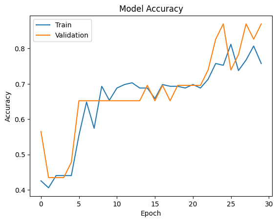

```python
plt.plot(history_1.history['accuracy'])
plt.plot(history_1.history['val_accuracy'])
plt.title('Model Accuracy')
plt.ylabel('Accuracy')
plt.xlabel('Epoch')
plt.legend(['Train', 'Validation'], loc='upper left')
plt.show()
```

**Observations:**

**Evaluate the model on test data**

```python
accuracy = model1.evaluate(X_test_normalized, y_test_encoded, verbose=2)
```

```
1/1 - 0s - 242ms/step - accuracy: 0.9615 - loss: 0.4704
```

**Plotting the Confusion Matrix**

```python
# Here we would get the output as probablities for each category
y_pred=model1.predict(X_test_normalized)
```

```
1/1 ━━━━━━━━━━━━━━━━━━━━ 0s 353ms/step
```

```
1/1 ━━━━━━━━━━━━━━━━━━━━ 0s 357ms/step
```

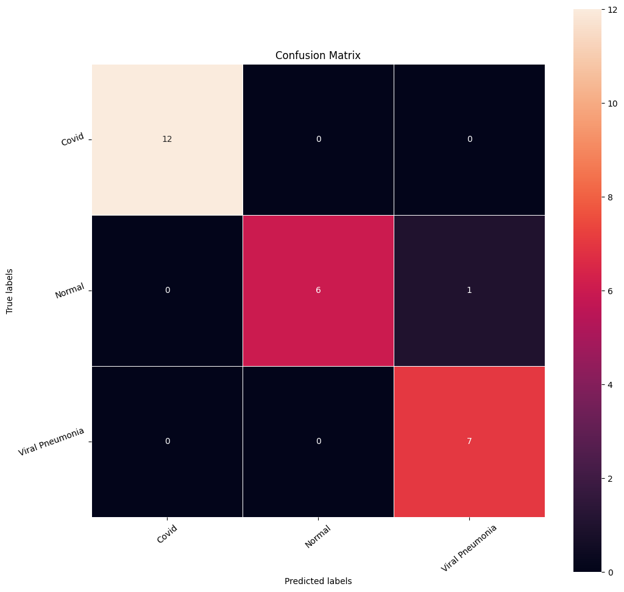

```python
# Obtaining the categorical values from y_test_encoded and y_pred
y_pred_arg=np.argmax(y_pred,axis=1)
y_test_arg=np.argmax(y_test_encoded,axis=1)

# Plotting the Confusion Matrix using confusion matrix() function which is also predefined in tensorflow module
confusion_matrix = tf.math.confusion_matrix(y_test_arg,y_pred_arg)
f, ax = plt.subplots(figsize=(12, 12))
sns.heatmap(
    confusion_matrix,
    annot=True,
    linewidths=.4,
    fmt="d",
    square=True,
    ax=ax
)
# Setting the labels to both the axes
ax.set_xlabel('Predicted labels');ax.set_ylabel('True labels');
ax.set_title('Confusion Matrix');
ax.xaxis.set_ticklabels(list(enc.classes_),rotation=40)
ax.yaxis.set_ticklabels(list(enc.classes_),rotation=20)
plt.show()
```

**Observations**

**Plotting Classification Report**

```python
from sklearn import metrics
#Accuracy as per the classification report
cr=metrics.classification_report(y_test_arg,y_pred_arg)
print(cr)
```

```
              precision    recall  f1-score   support

           0       1.00      1.00      1.00        12
           1       1.00      0.86      0.92         7
           2       0.88      1.00      0.93         7

    accuracy                           0.96        26
   macro avg       0.96      0.95      0.95        26
weighted avg       0.97      0.96      0.96        26
```

## Model Performance Improvement

**Reducing the Learning Rate:**

**Hint**: Use **ReduceLRonPlateau()** function that will be used to decrease the learning rate by some factor, if the loss is not decreasing for some time. This may start decreasing the loss at a smaller learning rate. There is a possibility that the loss may still not decrease. This may lead to executing the learning rate reduction again in an attempt to achieve a lower loss.

```python
learning_rate_reduction = ReduceLROnPlateau(monitor='val_accuracy',
                                            patience=3,
                                            verbose=1,
                                            factor=0.5,
                                            min_lr=0.0001)
```

### **Data Augmentation**

Remember, **data augmentation should not be used in the validation/test data set**.

```python
# Clearing backend
from tensorflow.keras import backend
backend.clear_session()

# Fixing the seed for random number generators
import random
np.random.seed(42)
random.seed(42)
tf.random.set_seed(42)
```

```python
# All images to be rescaled by 1/255.
train_datagen = ImageDataGenerator(
                              rotation_range=20,
                              #zoom_range=0.2,
                              #horizontal_flip=True,
                              #vertical_flip=True,
                              fill_mode='nearest'
                              )
# test_datagen  = ImageDataGenerator(rescale = 1.0/255.)
```

```python
# Intializing a sequential model
model2 = Sequential()

# Adding first conv layer with 64 filters and kernel size 3x3 , padding 'same' provides the output size same as the input siz
# Input_shape denotes input image dimension images
model2.add(Conv2D(64, (3,3), activation='relu', padding="same", input_shape=(64, 64, 3)))

# Add max pooling to reduce the size of output of first conv layer
model2.add(MaxPooling2D((2, 2), padding = 'same'))

# model.add(BatchNormalization())
model2.add(Conv2D(32, (3, 3), activation='relu', padding="same"))
model2.add(MaxPooling2D((2, 2), padding = 'same'))
model2.add(BatchNormalization())

# flattening the output of the conv layer after max pooling to make it ready for creating dense connections
model2.add(Flatten())

# Adding a fully connected dense layer with 16 neurons
model2.add(Dense(16, activation='relu'))
model2.add(Dropout(0.3))
# Add layer with 3 neurons and activation functions as softmax since this is a multi-class classification problem
model2.add(Dense(3, activation='softmax'))

# Complete the code to initialize Adam Optimimzer
opt=Adam()
# Complete the code to Compile model
model2.compile(optimizer=opt, loss='categorical_crossentropy', metrics=['accuracy'])

# Generating the summary of the model
model2.summary()
```

```
Model: "sequential"
```

```
┏━━━━━━━━━━━━━━━━━━━━━━━━━━━━━━━━━━━━━━┳━━━━━━━━━━━━━━━━━━━━━━━━━━━━━┳━━━━━━━━━━━━━━━━━┓
┃ Layer (type)                         ┃ Output Shape                ┃         Param # ┃
┡━━━━━━━━━━━━━━━━━━━━━━━━━━━━━━━━━━━━━━╇━━━━━━━━━━━━━━━━━━━━━━━━━━━━━╇━━━━━━━━━━━━━━━━━┩
│ conv2d (Conv2D)                      │ (None, 64, 64, 64)          │           1,792 │
├──────────────────────────────────────┼─────────────────────────────┼─────────────────┤
│ max_pooling2d (MaxPooling2D)         │ (None, 32, 32, 64)          │               0 │
├──────────────────────────────────────┼─────────────────────────────┼─────────────────┤
│ conv2d_1 (Conv2D)                    │ (None, 32, 32, 32)          │          18,464 │
├──────────────────────────────────────┼─────────────────────────────┼─────────────────┤
│ max_pooling2d_1 (MaxPooling2D)       │ (None, 16, 16, 32)          │               0 │
├──────────────────────────────────────┼─────────────────────────────┼─────────────────┤
│ batch_normalization                  │ (None, 16, 16, 32)          │             128 │
│ (BatchNormalization)                 │                             │                 │
├──────────────────────────────────────┼─────────────────────────────┼─────────────────┤
│ flatten (Flatten)                    │ (None, 8192)                │               0 │
├──────────────────────────────────────┼─────────────────────────────┼─────────────────┤
│ dense (Dense)                        │ (None, 16)                  │         131,088 │
├──────────────────────────────────────┼─────────────────────────────┼─────────────────┤
│ dropout (Dropout)                    │ (None, 16)                  │               0 │
├──────────────────────────────────────┼─────────────────────────────┼─────────────────┤
│ dense_1 (Dense)                      │ (None, 3)                   │              51 │
└──────────────────────────────────────┴─────────────────────────────┴─────────────────┘
```

```
 Total params: 151,523 (591.89 KB)
```

```
 Trainable params: 151,459 (591.64 KB)
```

```
 Non-trainable params: 64 (256.00 B)
```

**Fitting the model on the train data**

```python
# Epochs
epochs =30
# Batch size
batch_size = 64

history = model2.fit(train_datagen.flow(X_train_normalized,y_train_encoded,
                                       batch_size=batch_size,
                                       shuffle=False),
                                       epochs=epochs,
                                       steps_per_epoch=X_train_normalized.shape[0] // batch_size,
                                       validation_data=(X_val_normalized,y_val_encoded),
                                       verbose=1,callbacks=[learning_rate_reduction])
```

```
1/3 ━━━━━━━━━━━━━━━━━━━━ 4s 2s/step - accuracy: 0.1875 - loss: 1.6139
```

```
2/3 ━━━━━━━━━━━━━━━━━━━━ 0s 464ms/step - accuracy: 0.2852 - loss: 1.4802
```

```
3/3 ━━━━━━━━━━━━━━━━━━━━ 0s 460ms/step - accuracy: 0.3394 - loss: 1.3751
```

```
3/3 ━━━━━━━━━━━━━━━━━━━━ 4s 596ms/step - accuracy: 0.3665 - loss: 1.3225 - val_accuracy: 0.3478 - val_loss: 1.0396 - learning_rate: 0.0010
```

```
1/3 ━━━━━━━━━━━━━━━━━━━━ 0s 64ms/step - accuracy: 0.6000 - loss: 0.9992
```

```
3/3 ━━━━━━━━━━━━━━━━━━━━ 0s 32ms/step - accuracy: 0.6000 - loss: 0.9992 - val_accuracy: 0.3043 - val_loss: 1.0644 - learning_rate: 0.0010
```

```
1/3 ━━━━━━━━━━━━━━━━━━━━ 2s 1s/step - accuracy: 0.7500 - loss: 0.5844
```

```
2/3 ━━━━━━━━━━━━━━━━━━━━ 0s 473ms/step - accuracy: 0.7148 - loss: 0.6303
```

```
3/3 ━━━━━━━━━━━━━━━━━━━━ 0s 270ms/step - accuracy: 0.7084 - loss: 0.6430
```

```
3/3 ━━━━━━━━━━━━━━━━━━━━ 2s 301ms/step - accuracy: 0.7052 - loss: 0.6494 - val_accuracy: 0.3043 - val_loss: 1.1434 - learning_rate: 0.0010
```

```
1/3 ━━━━━━━━━━━━━━━━━━━━ 0s 454ms/step - accuracy: 0.7812 - loss: 0.5580
```

```
Epoch 4: ReduceLROnPlateau reducing learning rate to 0.0005000000237487257.
```

```
3/3 ━━━━━━━━━━━━━━━━━━━━ 1s 32ms/step - accuracy: 0.7812 - loss: 0.5580 - val_accuracy: 0.3043 - val_loss: 1.1544 - learning_rate: 0.0010
```

```
1/3 ━━━━━━━━━━━━━━━━━━━━ 1s 719ms/step - accuracy: 0.7500 - loss: 0.5470
```

```
2/3 ━━━━━━━━━━━━━━━━━━━━ 0s 461ms/step - accuracy: 0.7578 - loss: 0.5324
```

```
3/3 ━━━━━━━━━━━━━━━━━━━━ 0s 471ms/step - accuracy: 0.7604 - loss: 0.5245
```

```
3/3 ━━━━━━━━━━━━━━━━━━━━ 2s 501ms/step - accuracy: 0.7617 - loss: 0.5206 - val_accuracy: 0.3043 - val_loss: 1.1484 - learning_rate: 5.0000e-04
```

```
1/3 ━━━━━━━━━━━━━━━━━━━━ 0s 63ms/step - accuracy: 0.7000 - loss: 0.6555
```

```
3/3 ━━━━━━━━━━━━━━━━━━━━ 0s 33ms/step - accuracy: 0.7000 - loss: 0.6555 - val_accuracy: 0.3043 - val_loss: 1.1533 - learning_rate: 5.0000e-04
```

```
1/3 ━━━━━━━━━━━━━━━━━━━━ 1s 721ms/step - accuracy: 0.8594 - loss: 0.4093
```

```
2/3 ━━━━━━━━━━━━━━━━━━━━ 0s 458ms/step - accuracy: 0.8438 - loss: 0.4224
```

```
3/3 ━━━━━━━━━━━━━━━━━━━━ 0s 494ms/step - accuracy: 0.8507 - loss: 0.4065
```

```
Epoch 7: ReduceLROnPlateau reducing learning rate to 0.0002500000118743628.
```

```
3/3 ━━━━━━━━━━━━━━━━━━━━ 2s 584ms/step - accuracy: 0.8542 - loss: 0.3986 - val_accuracy: 0.3043 - val_loss: 1.1900 - learning_rate: 5.0000e-04
```

```
1/3 ━━━━━━━━━━━━━━━━━━━━ 0s 91ms/step - accuracy: 0.9000 - loss: 0.3122
```

```
3/3 ━━━━━━━━━━━━━━━━━━━━ 0s 50ms/step - accuracy: 0.9000 - loss: 0.3122 - val_accuracy: 0.3043 - val_loss: 1.1977 - learning_rate: 2.5000e-04
```

```
1/3 ━━━━━━━━━━━━━━━━━━━━ 0s 498ms/step - accuracy: 0.8000 - loss: 0.3462
```

```
2/3 ━━━━━━━━━━━━━━━━━━━━ 0s 771ms/step - accuracy: 0.8324 - loss: 0.3498
```

```
3/3 ━━━━━━━━━━━━━━━━━━━━ 0s 787ms/step - accuracy: 0.8327 - loss: 0.3623
```

```
3/3 ━━━━━━━━━━━━━━━━━━━━ 2s 832ms/step - accuracy: 0.8329 - loss: 0.3686 - val_accuracy: 0.3043 - val_loss: 1.2330 - learning_rate: 2.5000e-04
```

```
1/3 ━━━━━━━━━━━━━━━━━━━━ 1s 740ms/step - accuracy: 0.8594 - loss: 0.3265
```

```
Epoch 10: ReduceLROnPlateau reducing learning rate to 0.0001250000059371814.
```

```
3/3 ━━━━━━━━━━━━━━━━━━━━ 1s 54ms/step - accuracy: 0.8594 - loss: 0.3265 - val_accuracy: 0.3043 - val_loss: 1.2349 - learning_rate: 2.5000e-04
```

```
1/3 ━━━━━━━━━━━━━━━━━━━━ 5s 3s/step - accuracy: 0.8750 - loss: 0.3511
```

```
2/3 ━━━━━━━━━━━━━━━━━━━━ 0s 72ms/step - accuracy: 0.8834 - loss: 0.3396
```

```
3/3 ━━━━━━━━━━━━━━━━━━━━ 0s 266ms/step - accuracy: 0.8861 - loss: 0.3406
```

```
3/3 ━━━━━━━━━━━━━━━━━━━━ 3s 296ms/step - accuracy: 0.8874 - loss: 0.3411 - val_accuracy: 0.3043 - val_loss: 1.2224 - learning_rate: 1.2500e-04
```

```
1/3 ━━━━━━━━━━━━━━━━━━━━ 0s 473ms/step - accuracy: 0.7969 - loss: 0.4899
```

```
3/3 ━━━━━━━━━━━━━━━━━━━━ 1s 31ms/step - accuracy: 0.7969 - loss: 0.4899 - val_accuracy: 0.3043 - val_loss: 1.2132 - learning_rate: 1.2500e-04
```

```
1/3 ━━━━━━━━━━━━━━━━━━━━ 1s 703ms/step - accuracy: 0.8594 - loss: 0.3751
```

```
2/3 ━━━━━━━━━━━━━━━━━━━━ 0s 65ms/step - accuracy: 0.8554 - loss: 0.3879
```

```
3/3 ━━━━━━━━━━━━━━━━━━━━ 0s 268ms/step - accuracy: 0.8480 - loss: 0.3900
```

```
Epoch 13: ReduceLROnPlateau reducing learning rate to 0.0001.
```

```
3/3 ━━━━━━━━━━━━━━━━━━━━ 1s 299ms/step - accuracy: 0.8443 - loss: 0.3910 - val_accuracy: 0.3043 - val_loss: 1.1712 - learning_rate: 1.2500e-04
```

```
1/3 ━━━━━━━━━━━━━━━━━━━━ 0s 487ms/step - accuracy: 0.7656 - loss: 0.5454
```

```
3/3 ━━━━━━━━━━━━━━━━━━━━ 1s 31ms/step - accuracy: 0.7656 - loss: 0.5454 - val_accuracy: 0.3043 - val_loss: 1.1560 - learning_rate: 1.0000e-04
```

```
1/3 ━━━━━━━━━━━━━━━━━━━━ 2s 1s/step - accuracy: 0.8906 - loss: 0.3078
```

```
2/3 ━━━━━━━━━━━━━━━━━━━━ 0s 65ms/step - accuracy: 0.8845 - loss: 0.3150
```

```
3/3 ━━━━━━━━━━━━━━━━━━━━ 0s 261ms/step - accuracy: 0.8844 - loss: 0.3120
```

```
3/3 ━━━━━━━━━━━━━━━━━━━━ 2s 291ms/step - accuracy: 0.8843 - loss: 0.3105 - val_accuracy: 0.3043 - val_loss: 1.1123 - learning_rate: 1.0000e-04
```

```
1/3 ━━━━━━━━━━━━━━━━━━━━ 0s 471ms/step - accuracy: 0.8281 - loss: 0.4321
```

```
3/3 ━━━━━━━━━━━━━━━━━━━━ 1s 32ms/step - accuracy: 0.8281 - loss: 0.4321 - val_accuracy: 0.3043 - val_loss: 1.0966 - learning_rate: 1.0000e-04
```

```
1/3 ━━━━━━━━━━━━━━━━━━━━ 1s 715ms/step - accuracy: 0.8750 - loss: 0.3040
```

```
2/3 ━━━━━━━━━━━━━━━━━━━━ 0s 65ms/step - accuracy: 0.8767 - loss: 0.3020
```

```
3/3 ━━━━━━━━━━━━━━━━━━━━ 0s 262ms/step - accuracy: 0.8719 - loss: 0.3143
```

```
3/3 ━━━━━━━━━━━━━━━━━━━━ 1s 292ms/step - accuracy: 0.8695 - loss: 0.3204 - val_accuracy: 0.3043 - val_loss: 1.0566 - learning_rate: 1.0000e-04
```

```
1/3 ━━━━━━━━━━━━━━━━━━━━ 0s 462ms/step - accuracy: 0.9219 - loss: 0.3422
```

```
3/3 ━━━━━━━━━━━━━━━━━━━━ 1s 30ms/step - accuracy: 0.9219 - loss: 0.3422 - val_accuracy: 0.3043 - val_loss: 1.0451 - learning_rate: 1.0000e-04
```

```
1/3 ━━━━━━━━━━━━━━━━━━━━ 0s 313ms/step - accuracy: 0.8000 - loss: 0.5362
```

```
2/3 ━━━━━━━━━━━━━━━━━━━━ 0s 564ms/step - accuracy: 0.8324 - loss: 0.4910
```

```
3/3 ━━━━━━━━━━━━━━━━━━━━ 0s 686ms/step - accuracy: 0.8448 - loss: 0.4486
```

```
3/3 ━━━━━━━━━━━━━━━━━━━━ 2s 735ms/step - accuracy: 0.8510 - loss: 0.4274 - val_accuracy: 0.3043 - val_loss: 1.0222 - learning_rate: 1.0000e-04
```

```
1/3 ━━━━━━━━━━━━━━━━━━━━ 1s 770ms/step - accuracy: 0.9062 - loss: 0.3110
```

```
3/3 ━━━━━━━━━━━━━━━━━━━━ 1s 52ms/step - accuracy: 0.9062 - loss: 0.3110 - val_accuracy: 0.3043 - val_loss: 1.0146 - learning_rate: 1.0000e-04
```

```
1/3 ━━━━━━━━━━━━━━━━━━━━ 5s 3s/step - accuracy: 0.8000 - loss: 0.3339
```

```
2/3 ━━━━━━━━━━━━━━━━━━━━ 0s 460ms/step - accuracy: 0.8054 - loss: 0.3442
```

```
3/3 ━━━━━━━━━━━━━━━━━━━━ 0s 468ms/step - accuracy: 0.8099 - loss: 0.3633
```

```
3/3 ━━━━━━━━━━━━━━━━━━━━ 4s 498ms/step - accuracy: 0.8121 - loss: 0.3729 - val_accuracy: 0.3043 - val_loss: 0.9943 - learning_rate: 1.0000e-04
```

```
1/3 ━━━━━━━━━━━━━━━━━━━━ 0s 450ms/step - accuracy: 0.8594 - loss: 0.3130
```

```
3/3 ━━━━━━━━━━━━━━━━━━━━ 1s 31ms/step - accuracy: 0.8594 - loss: 0.3130 - val_accuracy: 0.3043 - val_loss: 0.9882 - learning_rate: 1.0000e-04
```

```
1/3 ━━━━━━━━━━━━━━━━━━━━ 2s 1s/step - accuracy: 0.8281 - loss: 0.3906
```

```
2/3 ━━━━━━━━━━━━━━━━━━━━ 0s 468ms/step - accuracy: 0.8438 - loss: 0.3569
```

```
3/3 ━━━━━━━━━━━━━━━━━━━━ 0s 470ms/step - accuracy: 0.8490 - loss: 0.3536
```

```
3/3 ━━━━━━━━━━━━━━━━━━━━ 2s 500ms/step - accuracy: 0.8516 - loss: 0.3519 - val_accuracy: 0.3043 - val_loss: 0.9669 - learning_rate: 1.0000e-04
```

```
1/3 ━━━━━━━━━━━━━━━━━━━━ 0s 63ms/step - accuracy: 0.9000 - loss: 0.2681
```

```
3/3 ━━━━━━━━━━━━━━━━━━━━ 0s 33ms/step - accuracy: 0.9000 - loss: 0.2681 - val_accuracy: 0.3043 - val_loss: 0.9622 - learning_rate: 1.0000e-04
```

```
1/3 ━━━━━━━━━━━━━━━━━━━━ 0s 309ms/step - accuracy: 1.0000 - loss: 0.2654
```

```
2/3 ━━━━━━━━━━━━━━━━━━━━ 0s 464ms/step - accuracy: 0.9662 - loss: 0.2662
```

```
3/3 ━━━━━━━━━━━━━━━━━━━━ 0s 472ms/step - accuracy: 0.9437 - loss: 0.2796
```

```
3/3 ━━━━━━━━━━━━━━━━━━━━ 1s 503ms/step - accuracy: 0.9324 - loss: 0.2863 - val_accuracy: 0.3043 - val_loss: 0.9562 - learning_rate: 1.0000e-04
```

```
1/3 ━━━━━━━━━━━━━━━━━━━━ 0s 457ms/step - accuracy: 0.8906 - loss: 0.2990
```

```
3/3 ━━━━━━━━━━━━━━━━━━━━ 1s 37ms/step - accuracy: 0.8906 - loss: 0.2990 - val_accuracy: 0.3043 - val_loss: 0.9543 - learning_rate: 1.0000e-04
```

```
1/3 ━━━━━━━━━━━━━━━━━━━━ 2s 1s/step - accuracy: 0.9219 - loss: 0.2892
```

```
2/3 ━━━━━━━━━━━━━━━━━━━━ 0s 458ms/step - accuracy: 0.9102 - loss: 0.3062
```

```
3/3 ━━━━━━━━━━━━━━━━━━━━ 0s 261ms/step - accuracy: 0.9087 - loss: 0.3081
```

```
3/3 ━━━━━━━━━━━━━━━━━━━━ 2s 292ms/step - accuracy: 0.9080 - loss: 0.3091 - val_accuracy: 0.3043 - val_loss: 0.9447 - learning_rate: 1.0000e-04
```

```
1/3 ━━━━━━━━━━━━━━━━━━━━ 0s 467ms/step - accuracy: 0.8594 - loss: 0.3070
```

```
3/3 ━━━━━━━━━━━━━━━━━━━━ 1s 31ms/step - accuracy: 0.8594 - loss: 0.3070 - val_accuracy: 0.3043 - val_loss: 0.9423 - learning_rate: 1.0000e-04
```

```
1/3 ━━━━━━━━━━━━━━━━━━━━ 1s 884ms/step - accuracy: 0.8594 - loss: 0.3623
```

```
2/3 ━━━━━━━━━━━━━━━━━━━━ 0s 783ms/step - accuracy: 0.8633 - loss: 0.3772
```

```
3/3 ━━━━━━━━━━━━━━━━━━━━ 0s 456ms/step - accuracy: 0.8678 - loss: 0.3775
```

```
3/3 ━━━━━━━━━━━━━━━━━━━━ 2s 504ms/step - accuracy: 0.8700 - loss: 0.3777 - val_accuracy: 0.3913 - val_loss: 0.9289 - learning_rate: 1.0000e-04
```

```
1/3 ━━━━━━━━━━━━━━━━━━━━ 1s 802ms/step - accuracy: 0.8281 - loss: 0.3316
```

```
3/3 ━━━━━━━━━━━━━━━━━━━━ 1s 47ms/step - accuracy: 0.8281 - loss: 0.3316 - val_accuracy: 0.3913 - val_loss: 0.9239 - learning_rate: 1.0000e-04
```

**Model Evaluation**

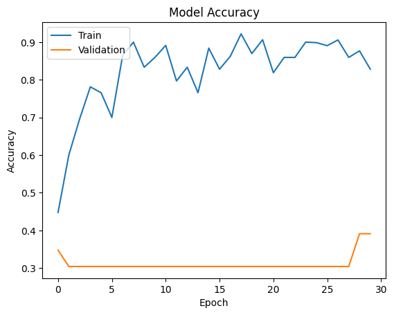

```python
plt.plot(history.history['accuracy'])
plt.plot(history.history['val_accuracy'])
plt.title('Model Accuracy')
plt.ylabel('Accuracy')
plt.xlabel('Epoch')
plt.legend(['Train', 'Validation'], loc='upper left')
plt.show()
```

**Evaluate the model on test data**

```python
accuracy = model2.evaluate(X_test_normalized, y_test_encoded, verbose=2)
```

```
1/1 - 0s - 68ms/step - accuracy: 0.5385 - loss: 0.9332
```

We can observe that our accuracy decreased compared to our previous model.

**Evaluate the model on test data**

```python
# Here we would get the output as probablities for each category
y_pred=model2.predict(X_test_normalized)
```

```
1/1 ━━━━━━━━━━━━━━━━━━━━ 0s 117ms/step
```

```
1/1 ━━━━━━━━━━━━━━━━━━━━ 0s 118ms/step
```

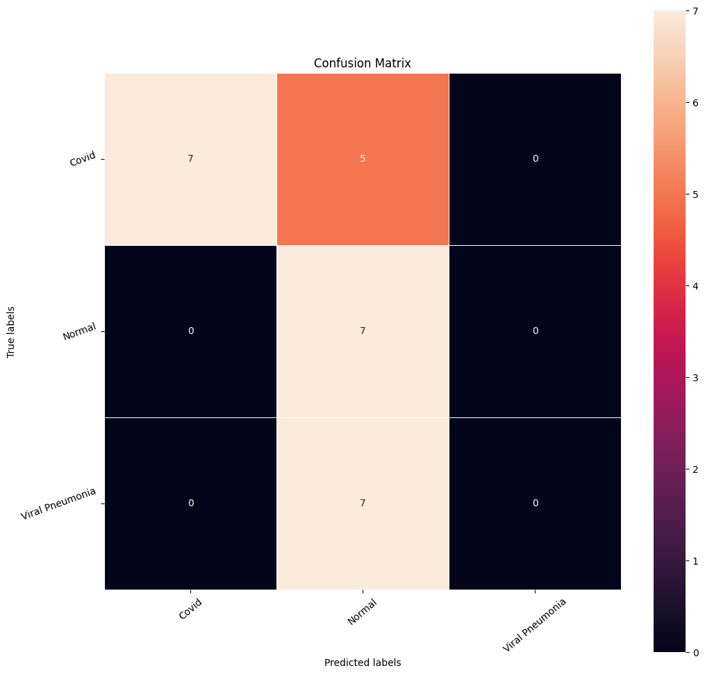

```python
# Obtaining the categorical values from y_test_encoded and y_pred
y_pred_arg=np.argmax(y_pred,axis=1)
y_test_arg=np.argmax(y_test_encoded,axis=1)

# Plotting the Confusion Matrix using confusion matrix() function which is also predefined in tensorflow module
confusion_matrix = tf.math.confusion_matrix(y_test_arg,y_pred_arg)
f, ax = plt.subplots(figsize=(12, 12))
sns.heatmap(
    confusion_matrix,
    annot=True,
    linewidths=.4,
    fmt="d",
    square=True,
    ax=ax
)
# Setting the labels to both the axes
ax.set_xlabel('Predicted labels');ax.set_ylabel('True labels');
ax.set_title('Confusion Matrix');
ax.xaxis.set_ticklabels(list(enc.classes_),rotation=40)
ax.yaxis.set_ticklabels(list(enc.classes_),rotation=20)
plt.show()
```

**Observation:**

**Plotting Classification Report**

```python
from sklearn import metrics
#Accuracy as per the classification report
cr=metrics.classification_report(y_test_arg,y_pred_arg)
print(cr)
```

```
              precision    recall  f1-score   support

           0       1.00      0.58      0.74        12
           1       0.37      1.00      0.54         7
           2       0.00      0.00      0.00         7

    accuracy                           0.54        26
   macro avg       0.46      0.53      0.43        26
weighted avg       0.56      0.54      0.49        26
```

# Transfer Learning using VGG16

```python
# Clearing backend
from tensorflow.keras import backend
backend.clear_session()

# Fixing the seed for random number generators
import random
np.random.seed(42)
random.seed(42)
tf.random.set_seed(42)
```

```python
from tensorflow.keras.models import Model
from keras.applications.vgg16 import VGG16

vgg_model = VGG16(weights='imagenet', include_top = False, input_shape = (64,64,3))
vgg_model.summary()
```

```
Downloading data from https://storage.googleapis.com/tensorflow/keras-applications/vgg16/vgg16_weights_tf_dim_ordering_tf_kernels_notop.h5
```

```
       0/58889256 ━━━━━━━━━━━━━━━━━━━━ 0s 0s/step
```

```
 7127040/58889256 ━━━━━━━━━━━━━━━━━━━━ 0s 0us/step
```

```
11722752/58889256 ━━━━━━━━━━━━━━━━━━━━ 0s 0us/step
```

```
26009600/58889256 ━━━━━━━━━━━━━━━━━━━━ 0s 0us/step
```

```
40214528/58889256 ━━━━━━━━━━━━━━━━━━━━ 0s 0us/step
```

```
55197696/58889256 ━━━━━━━━━━━━━━━━━━━━ 0s 0us/step
```

```
58889256/58889256 ━━━━━━━━━━━━━━━━━━━━ 0s 0us/step
```

```
Model: "vgg16"
```

```
┏━━━━━━━━━━━━━━━━━━━━━━━━━━━━━━━━━━━━━━┳━━━━━━━━━━━━━━━━━━━━━━━━━━━━━┳━━━━━━━━━━━━━━━━━┓
┃ Layer (type)                         ┃ Output Shape                ┃         Param # ┃
┡━━━━━━━━━━━━━━━━━━━━━━━━━━━━━━━━━━━━━━╇━━━━━━━━━━━━━━━━━━━━━━━━━━━━━╇━━━━━━━━━━━━━━━━━┩
│ input_layer (InputLayer)             │ (None, 64, 64, 3)           │               0 │
├──────────────────────────────────────┼─────────────────────────────┼─────────────────┤
│ block1_conv1 (Conv2D)                │ (None, 64, 64, 64)          │           1,792 │
├──────────────────────────────────────┼─────────────────────────────┼─────────────────┤
│ block1_conv2 (Conv2D)                │ (None, 64, 64, 64)          │          36,928 │
├──────────────────────────────────────┼─────────────────────────────┼─────────────────┤
│ block1_pool (MaxPooling2D)           │ (None, 32, 32, 64)          │               0 │
├──────────────────────────────────────┼─────────────────────────────┼─────────────────┤
│ block2_conv1 (Conv2D)                │ (None, 32, 32, 128)         │          73,856 │
├──────────────────────────────────────┼─────────────────────────────┼─────────────────┤
│ block2_conv2 (Conv2D)                │ (None, 32, 32, 128)         │         147,584 │
├──────────────────────────────────────┼─────────────────────────────┼─────────────────┤
│ block2_pool (MaxPooling2D)           │ (None, 16, 16, 128)         │               0 │
├──────────────────────────────────────┼─────────────────────────────┼─────────────────┤
│ block3_conv1 (Conv2D)                │ (None, 16, 16, 256)         │         295,168 │
├──────────────────────────────────────┼─────────────────────────────┼─────────────────┤
│ block3_conv2 (Conv2D)                │ (None, 16, 16, 256)         │         590,080 │
├──────────────────────────────────────┼─────────────────────────────┼─────────────────┤
│ block3_conv3 (Conv2D)                │ (None, 16, 16, 256)         │         590,080 │
├──────────────────────────────────────┼─────────────────────────────┼─────────────────┤
│ block3_pool (MaxPooling2D)           │ (None, 8, 8, 256)           │               0 │
├──────────────────────────────────────┼─────────────────────────────┼─────────────────┤
│ block4_conv1 (Conv2D)                │ (None, 8, 8, 512)           │       1,180,160 │
├──────────────────────────────────────┼─────────────────────────────┼─────────────────┤
│ block4_conv2 (Conv2D)                │ (None, 8, 8, 512)           │       2,359,808 │
├──────────────────────────────────────┼─────────────────────────────┼─────────────────┤
│ block4_conv3 (Conv2D)                │ (None, 8, 8, 512)           │       2,359,808 │
├──────────────────────────────────────┼─────────────────────────────┼─────────────────┤
│ block4_pool (MaxPooling2D)           │ (None, 4, 4, 512)           │               0 │
├──────────────────────────────────────┼─────────────────────────────┼─────────────────┤
│ block5_conv1 (Conv2D)                │ (None, 4, 4, 512)           │       2,359,808 │
├──────────────────────────────────────┼─────────────────────────────┼─────────────────┤
│ block5_conv2 (Conv2D)                │ (None, 4, 4, 512)           │       2,359,808 │
├──────────────────────────────────────┼─────────────────────────────┼─────────────────┤
│ block5_conv3 (Conv2D)                │ (None, 4, 4, 512)           │       2,359,808 │
├──────────────────────────────────────┼─────────────────────────────┼─────────────────┤
│ block5_pool (MaxPooling2D)           │ (None, 2, 2, 512)           │               0 │
└──────────────────────────────────────┴─────────────────────────────┴─────────────────┘
```

```
 Total params: 14,714,688 (56.13 MB)
```

```
 Trainable params: 14,714,688 (56.13 MB)
```

```
 Non-trainable params: 0 (0.00 B)
```

```python
# Making all the layers of the VGG model non-trainable. i.e. freezing them
for layer in vgg_model.layers:
    layer.trainable = False
```

```python
from tensorflow.keras.layers import Input

vgg16_model = Sequential()

# Define input shape
input_shape = (64, 64, 3)

# Create a new Functional model
input_tensor = Input(shape=input_shape)  # Define an Input layer
x = vgg_model(input_tensor)             # Pass the input through the VGG16 model
x = BatchNormalization()(x)
x = Flatten()(x)                        # Flatten the output
x = Dense(32, activation='relu')(x)     # Add a Dense layer
x = Dropout(0.3)(x)                     # Add a Dropout layer
x = Dense(16, activation='relu')(x)     # Add another Dense layer
output_tensor = Dense(3, activation='softmax')(x) # Add the output layer

# Create the model
vgg16_model = Model(inputs=input_tensor, outputs=output_tensor)

opt=Adam()
# Compile model
vgg16_model.compile(optimizer=opt, loss='categorical_crossentropy', metrics=['accuracy'])

# Generating the summary of the model
vgg16_model.summary()
```

```
Model: "functional"
```

```
┏━━━━━━━━━━━━━━━━━━━━━━━━━━━━━━━━━━━━━━┳━━━━━━━━━━━━━━━━━━━━━━━━━━━━━┳━━━━━━━━━━━━━━━━━┓
┃ Layer (type)                         ┃ Output Shape                ┃         Param # ┃
┡━━━━━━━━━━━━━━━━━━━━━━━━━━━━━━━━━━━━━━╇━━━━━━━━━━━━━━━━━━━━━━━━━━━━━╇━━━━━━━━━━━━━━━━━┩
│ input_layer_1 (InputLayer)           │ (None, 64, 64, 3)           │               0 │
├──────────────────────────────────────┼─────────────────────────────┼─────────────────┤
│ vgg16 (Functional)                   │ (None, 2, 2, 512)           │      14,714,688 │
├──────────────────────────────────────┼─────────────────────────────┼─────────────────┤
│ batch_normalization                  │ (None, 2, 2, 512)           │           2,048 │
│ (BatchNormalization)                 │                             │                 │
├──────────────────────────────────────┼─────────────────────────────┼─────────────────┤
│ flatten (Flatten)                    │ (None, 2048)                │               0 │
├──────────────────────────────────────┼─────────────────────────────┼─────────────────┤
│ dense (Dense)                        │ (None, 32)                  │          65,568 │
├──────────────────────────────────────┼─────────────────────────────┼─────────────────┤
│ dropout (Dropout)                    │ (None, 32)                  │               0 │
├──────────────────────────────────────┼─────────────────────────────┼─────────────────┤
│ dense_1 (Dense)                      │ (None, 16)                  │             528 │
├──────────────────────────────────────┼─────────────────────────────┼─────────────────┤
│ dense_2 (Dense)                      │ (None, 3)                   │              51 │
└──────────────────────────────────────┴─────────────────────────────┴─────────────────┘
```

```
 Total params: 14,782,883 (56.39 MB)
```

```
 Trainable params: 67,171 (262.39 KB)
```

```
 Non-trainable params: 14,715,712 (56.14 MB)
```

```python
# Epochs
epochs = 25
# Batch size
batch_size = 64

history_vgg16 = vgg16_model.fit(train_datagen.flow(X_train_normalized,y_train_encoded,
                                       batch_size=batch_size,
                                       seed=42,
                                       shuffle=False),
                    epochs=epochs,
                    steps_per_epoch=X_train_normalized.shape[0] // batch_size,
                    validation_data=(X_val_normalized,y_val_encoded),
                    verbose=1)
```

```
1/3 ━━━━━━━━━━━━━━━━━━━━ 9s 5s/step - accuracy: 0.4531 - loss: 1.0953
```

```
2/3 ━━━━━━━━━━━━━━━━━━━━ 0s 386ms/step - accuracy: 0.4495 - loss: 1.0966
```

```
3/3 ━━━━━━━━━━━━━━━━━━━━ 0s 2s/step - accuracy: 0.4712 - loss: 1.0524
```

```
3/3 ━━━━━━━━━━━━━━━━━━━━ 10s 3s/step - accuracy: 0.4820 - loss: 1.0302 - val_accuracy: 0.3043 - val_loss: 1.1072
```

```
1/3 ━━━━━━━━━━━━━━━━━━━━ 7s 4s/step - accuracy: 0.7031 - loss: 0.7889
```

```
3/3 ━━━━━━━━━━━━━━━━━━━━ 5s 434ms/step - accuracy: 0.7031 - loss: 0.7889 - val_accuracy: 0.3478 - val_loss: 1.0722
```

```
1/3 ━━━━━━━━━━━━━━━━━━━━ 1s 631ms/step - accuracy: 0.7000 - loss: 0.7794
```

```
2/3 ━━━━━━━━━━━━━━━━━━━━ 2s 2s/step - accuracy: 0.7216 - loss: 0.6978
```

```
3/3 ━━━━━━━━━━━━━━━━━━━━ 0s 2s/step - accuracy: 0.7395 - loss: 0.6602
```

```
3/3 ━━━━━━━━━━━━━━━━━━━━ 6s 3s/step - accuracy: 0.7485 - loss: 0.6414 - val_accuracy: 0.3913 - val_loss: 0.9854
```

```
1/3 ━━━━━━━━━━━━━━━━━━━━ 5s 3s/step - accuracy: 0.8125 - loss: 0.4663
```

```
3/3 ━━━━━━━━━━━━━━━━━━━━ 4s 747ms/step - accuracy: 0.8125 - loss: 0.4663 - val_accuracy: 0.3913 - val_loss: 0.9529
```

```
1/3 ━━━━━━━━━━━━━━━━━━━━ 21s 11s/step - accuracy: 0.9000 - loss: 0.3764
```

```
2/3 ━━━━━━━━━━━━━━━━━━━━ 3s 3s/step - accuracy: 0.8622 - loss: 0.4479
```

```
3/3 ━━━━━━━━━━━━━━━━━━━━ 0s 4s/step - accuracy: 0.8526 - loss: 0.4662
```

```
3/3 ━━━━━━━━━━━━━━━━━━━━ 19s 4s/step - accuracy: 0.8477 - loss: 0.4754 - val_accuracy: 0.5217 - val_loss: 0.8633
```

```
1/3 ━━━━━━━━━━━━━━━━━━━━ 4s 2s/step - accuracy: 0.7812 - loss: 0.5302
```

```
3/3 ━━━━━━━━━━━━━━━━━━━━ 3s 436ms/step - accuracy: 0.7812 - loss: 0.5302 - val_accuracy: 0.5217 - val_loss: 0.8365
```

```
1/3 ━━━━━━━━━━━━━━━━━━━━ 5s 3s/step - accuracy: 0.8438 - loss: 0.4751
```

```
2/3 ━━━━━━━━━━━━━━━━━━━━ 2s 2s/step - accuracy: 0.8398 - loss: 0.4671
```

```
3/3 ━━━━━━━━━━━━━━━━━━━━ 0s 3s/step - accuracy: 0.8411 - loss: 0.4528
```

```
3/3 ━━━━━━━━━━━━━━━━━━━━ 10s 4s/step - accuracy: 0.8418 - loss: 0.4457 - val_accuracy: 0.5217 - val_loss: 0.7694
```

```
1/3 ━━━━━━━━━━━━━━━━━━━━ 1s 729ms/step - accuracy: 0.7000 - loss: 0.6389
```

```
3/3 ━━━━━━━━━━━━━━━━━━━━ 2s 536ms/step - accuracy: 0.7000 - loss: 0.6389 - val_accuracy: 0.5217 - val_loss: 0.7581
```

```
1/3 ━━━━━━━━━━━━━━━━━━━━ 5s 3s/step - accuracy: 0.8906 - loss: 0.3019
```

```
2/3 ━━━━━━━━━━━━━━━━━━━━ 0s 371ms/step - accuracy: 0.8845 - loss: 0.3086
```

```
3/3 ━━━━━━━━━━━━━━━━━━━━ 0s 1s/step - accuracy: 0.8819 - loss: 0.3153
```

```
3/3 ━━━━━━━━━━━━━━━━━━━━ 6s 2s/step - accuracy: 0.8807 - loss: 0.3187 - val_accuracy: 0.5217 - val_loss: 0.7377
```

```
1/3 ━━━━━━━━━━━━━━━━━━━━ 4s 2s/step - accuracy: 0.8750 - loss: 0.4708
```

```
3/3 ━━━━━━━━━━━━━━━━━━━━ 3s 490ms/step - accuracy: 0.8750 - loss: 0.4708 - val_accuracy: 0.5217 - val_loss: 0.7305
```

```
1/3 ━━━━━━━━━━━━━━━━━━━━ 9s 5s/step - accuracy: 0.9375 - loss: 0.2121
```

```
2/3 ━━━━━━━━━━━━━━━━━━━━ 2s 2s/step - accuracy: 0.9297 - loss: 0.2446
```

```
3/3 ━━━━━━━━━━━━━━━━━━━━ 0s 2s/step - accuracy: 0.9219 - loss: 0.2635
```

```
3/3 ━━━━━━━━━━━━━━━━━━━━ 11s 3s/step - accuracy: 0.9180 - loss: 0.2729 - val_accuracy: 0.5217 - val_loss: 0.6999
```

```
1/3 ━━━━━━━━━━━━━━━━━━━━ 0s 371ms/step - accuracy: 1.0000 - loss: 0.0797
```

```
3/3 ━━━━━━━━━━━━━━━━━━━━ 1s 438ms/step - accuracy: 1.0000 - loss: 0.0797 - val_accuracy: 0.5217 - val_loss: 0.6888
```

```
1/3 ━━━━━━━━━━━━━━━━━━━━ 1s 615ms/step - accuracy: 0.8000 - loss: 0.2302
```

```
2/3 ━━━━━━━━━━━━━━━━━━━━ 2s 2s/step - accuracy: 0.8392 - loss: 0.2561
```

```
3/3 ━━━━━━━━━━━━━━━━━━━━ 0s 3s/step - accuracy: 0.8541 - loss: 0.2733
```

```
3/3 ━━━━━━━━━━━━━━━━━━━━ 9s 4s/step - accuracy: 0.8616 - loss: 0.2819 - val_accuracy: 0.5217 - val_loss: 0.6662
```

```
1/3 ━━━━━━━━━━━━━━━━━━━━ 4s 2s/step - accuracy: 0.8750 - loss: 0.2991
```

```
3/3 ━━━━━━━━━━━━━━━━━━━━ 3s 428ms/step - accuracy: 0.8750 - loss: 0.2991 - val_accuracy: 0.5217 - val_loss: 0.6569
```

```
1/3 ━━━━━━━━━━━━━━━━━━━━ 5s 3s/step - accuracy: 0.8594 - loss: 0.2995
```

```
2/3 ━━━━━━━━━━━━━━━━━━━━ 2s 2s/step - accuracy: 0.8672 - loss: 0.2969
```

```
3/3 ━━━━━━━━━━━━━━━━━━━━ 0s 3s/step - accuracy: 0.8767 - loss: 0.2861
```

```
3/3 ━━━━━━━━━━━━━━━━━━━━ 10s 3s/step - accuracy: 0.8815 - loss: 0.2807 - val_accuracy: 0.6522 - val_loss: 0.6308
```

```
1/3 ━━━━━━━━━━━━━━━━━━━━ 1s 657ms/step - accuracy: 1.0000 - loss: 0.0484
```

```
3/3 ━━━━━━━━━━━━━━━━━━━━ 2s 858ms/step - accuracy: 1.0000 - loss: 0.0484 - val_accuracy: 0.6522 - val_loss: 0.6227
```

```
1/3 ━━━━━━━━━━━━━━━━━━━━ 9s 5s/step - accuracy: 0.8906 - loss: 0.2230
```

```
2/3 ━━━━━━━━━━━━━━━━━━━━ 0s 536ms/step - accuracy: 0.8913 - loss: 0.2255
```

```
3/3 ━━━━━━━━━━━━━━━━━━━━ 0s 1s/step - accuracy: 0.8961 - loss: 0.2206
```

```
3/3 ━━━━━━━━━━━━━━━━━━━━ 9s 2s/step - accuracy: 0.8985 - loss: 0.2182 - val_accuracy: 0.6522 - val_loss: 0.6125
```

```
1/3 ━━━━━━━━━━━━━━━━━━━━ 4s 2s/step - accuracy: 0.9531 - loss: 0.1630
```

```
3/3 ━━━━━━━━━━━━━━━━━━━━ 3s 455ms/step - accuracy: 0.9531 - loss: 0.1630 - val_accuracy: 0.6522 - val_loss: 0.6146
```

```
1/3 ━━━━━━━━━━━━━━━━━━━━ 8s 4s/step - accuracy: 0.8906 - loss: 0.2758
```

```
2/3 ━━━━━━━━━━━━━━━━━━━━ 2s 3s/step - accuracy: 0.9062 - loss: 0.2536
```

```
3/3 ━━━━━━━━━━━━━━━━━━━━ 0s 2s/step - accuracy: 0.9133 - loss: 0.2429
```

```
3/3 ━━━━━━━━━━━━━━━━━━━━ 9s 2s/step - accuracy: 0.9169 - loss: 0.2375 - val_accuracy: 0.6522 - val_loss: 0.6251
```

```
1/3 ━━━━━━━━━━━━━━━━━━━━ 4s 2s/step - accuracy: 0.9375 - loss: 0.1684
```

```
3/3 ━━━━━━━━━━━━━━━━━━━━ 3s 435ms/step - accuracy: 0.9375 - loss: 0.1684 - val_accuracy: 0.6522 - val_loss: 0.6260
```

```
1/3 ━━━━━━━━━━━━━━━━━━━━ 22s 11s/step - accuracy: 0.9375 - loss: 0.2684
```

```
2/3 ━━━━━━━━━━━━━━━━━━━━ 0s 384ms/step - accuracy: 0.9417 - loss: 0.2521
```

```
3/3 ━━━━━━━━━━━━━━━━━━━━ 0s 1s/step - accuracy: 0.9442 - loss: 0.2344
```

```
3/3 ━━━━━━━━━━━━━━━━━━━━ 15s 2s/step - accuracy: 0.9455 - loss: 0.2256 - val_accuracy: 0.6087 - val_loss: 0.6244
```

```
1/3 ━━━━━━━━━━━━━━━━━━━━ 6s 3s/step - accuracy: 0.9531 - loss: 0.1637
```

```
3/3 ━━━━━━━━━━━━━━━━━━━━ 5s 758ms/step - accuracy: 0.9531 - loss: 0.1637 - val_accuracy: 0.6522 - val_loss: 0.6234
```

```
1/3 ━━━━━━━━━━━━━━━━━━━━ 25s 13s/step - accuracy: 0.9062 - loss: 0.2996
```

```
2/3 ━━━━━━━━━━━━━━━━━━━━ 0s 676ms/step - accuracy: 0.9126 - loss: 0.2837
```

```
3/3 ━━━━━━━━━━━━━━━━━━━━ 0s 2s/step - accuracy: 0.9176 - loss: 0.2687
```

```
3/3 ━━━━━━━━━━━━━━━━━━━━ 18s 3s/step - accuracy: 0.9201 - loss: 0.2611 - val_accuracy: 0.6522 - val_loss: 0.6142
```

```
1/3 ━━━━━━━━━━━━━━━━━━━━ 4s 2s/step - accuracy: 0.9531 - loss: 0.1311
```

```
3/3 ━━━━━━━━━━━━━━━━━━━━ 3s 438ms/step - accuracy: 0.9531 - loss: 0.1311 - val_accuracy: 0.6522 - val_loss: 0.6096
```

```
1/3 ━━━━━━━━━━━━━━━━━━━━ 22s 11s/step - accuracy: 0.9531 - loss: 0.1163
```

```
2/3 ━━━━━━━━━━━━━━━━━━━━ 2s 2s/step - accuracy: 0.9570 - loss: 0.1171
```

```
3/3 ━━━━━━━━━━━━━━━━━━━━ 0s 1s/step - accuracy: 0.9569 - loss: 0.1181
```

```
3/3 ━━━━━━━━━━━━━━━━━━━━ 15s 2s/step - accuracy: 0.9568 - loss: 0.1185 - val_accuracy: 0.6522 - val_loss: 0.5916
```

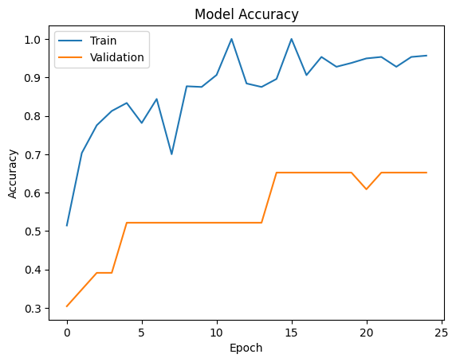

```python
plt.plot(history_vgg16.history['accuracy'])
plt.plot(history_vgg16.history['val_accuracy'])
plt.title('Model Accuracy')
plt.ylabel('Accuracy')
plt.xlabel('Epoch')
plt.legend(['Train', 'Validation'], loc='upper left')
plt.show()
```

### Accuracy of the VGG16 Model

```python
# Getting the accuracy of the model
accuracy = vgg16_model.evaluate(X_test_normalized, y_test_encoded, verbose=2)
```

```
1/1 - 1s - 1s/step - accuracy: 0.6154 - loss: 0.6921
```

```python
# Here we would get the output as probablities for each category
y_pred=vgg16_model.predict(X_test_normalized)
```

```
1/1 ━━━━━━━━━━━━━━━━━━━━ 0s 1s/step
```

```
1/1 ━━━━━━━━━━━━━━━━━━━━ 1s 1s/step
```

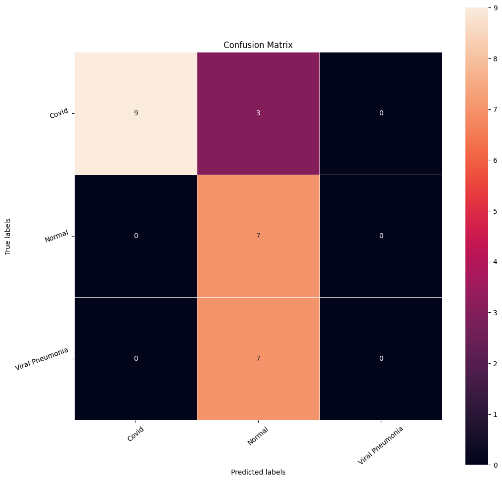

```python
# Obtaining the categorical values from y_test_encoded and y_pred
y_pred_arg=np.argmax(y_pred,axis=1)
y_test_arg=np.argmax(y_test_encoded,axis=1)

# Plotting the Confusion Matrix using confusion matrix() function which is also predefined in tensorflow module
confusion_matrix = tf.math.confusion_matrix(y_test_arg,y_pred_arg)
f, ax = plt.subplots(figsize=(12, 12))
sns.heatmap(
    confusion_matrix,
    annot=True,
    linewidths=.4,
    fmt="d",
    square=True,
    ax=ax
)
# Setting the labels to both the axes
ax.set_xlabel('Predicted labels');ax.set_ylabel('True labels');
ax.set_title('Confusion Matrix');
ax.xaxis.set_ticklabels(list(enc.classes_),rotation=40)
ax.yaxis.set_ticklabels(list(enc.classes_),rotation=20)
plt.show()
```

```python
from sklearn import metrics
#Accuracy as per the classification report
cr=metrics.classification_report(y_test_arg,y_pred_arg)
print(cr)
```

```
              precision    recall  f1-score   support

           0       1.00      0.75      0.86        12
           1       0.41      1.00      0.58         7
           2       0.00      0.00      0.00         7

    accuracy                           0.62        26
   macro avg       0.47      0.58      0.48        26
weighted avg       0.57      0.62      0.55        26
```

# Final Model

### Visualizing the prediction

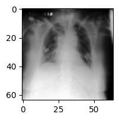

```
1/1 ━━━━━━━━━━━━━━━━━━━━ 0s 245ms/step
```

```
1/1 ━━━━━━━━━━━━━━━━━━━━ 0s 246ms/step
```

```
Predicted Label ['Covid']
True Label Covid
```

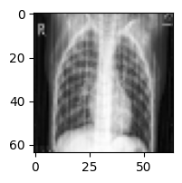

```
1/1 ━━━━━━━━━━━━━━━━━━━━ 0s 99ms/step
```

```
1/1 ━━━━━━━━━━━━━━━━━━━━ 0s 102ms/step
```

```
Predicted Label ['Covid']
True Label Viral Pneumonia
```

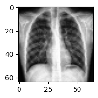

```
1/1 ━━━━━━━━━━━━━━━━━━━━ 0s 103ms/step
```

```
1/1 ━━━━━━━━━━━━━━━━━━━━ 0s 106ms/step
```

```
Predicted Label ['Normal']
True Label Normal
```

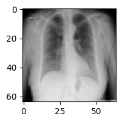

```
1/1 ━━━━━━━━━━━━━━━━━━━━ 0s 100ms/step
```

```
1/1 ━━━━━━━━━━━━━━━━━━━━ 0s 103ms/step
```

```
Predicted Label ['Normal']
True Label Covid
```

```python
# Visualizing the predicted and correct label of images from test data
plt.figure(figsize=(2,2))
plt.imshow(X_test[2])
plt.show()
## Complete the code to predict the test data using the final model selected
print('Predicted Label', enc.inverse_transform(vgg16_model.predict((X_test_normalized[2].reshape(1,64,64,3)))))   # reshaping the input image as we are only trying to predict using a single image
print('True Label', enc.inverse_transform(y_test_encoded)[2])                                               # using inverse_transform() to get the output label from the output vector

plt.figure(figsize=(2,2))
plt.imshow(X_test[10])
plt.show()
## Complete the code to predict the test data using the final model selected
print('Predicted Label', enc.inverse_transform(vgg16_model.predict((X_test_normalized[5].reshape(1,64,64,3)))))  # reshaping the input image as we are only trying to predict using a single image
print('True Label', enc.inverse_transform(y_test_encoded)[10])                                              # using inverse_transform() to get the output label from the output vector

plt.figure(figsize=(2,2))
plt.imshow(X_test[20],)
plt.show()
## Complete the code to predict the test data using the final model selected
print('Predicted Label', enc.inverse_transform(vgg16_model.predict((X_test_normalized[15].reshape(1,64,64,3)))))  # reshaping the input image as we are only trying to predict using a single image
print('True Label', enc.inverse_transform(y_test_encoded)[20])                                              # using inverse_transform() to get the output label from the output vector

plt.figure(figsize=(2,2))
plt.imshow(X_test[5])
plt.show()
## Complete the code to predict the test data using the final model selected
print('Predicted Label', enc.inverse_transform(vgg16_model.predict((X_test_normalized[25].reshape(1,64,64,3)))))  # reshaping the input image as we are only trying to predict using a single image
print('True Label', enc.inverse_transform(y_test_encoded)[5])
```

## Scope of Improvement

- More images can help improve the classification task.
- These models can be further improved by training with different filter sizes and different number of filters.
- These models can also be trained on the original image_size i.e 128 x 128 rather than being reduced to 64.